# Real Estate

```r
# Group by LISTING_ST and calculate mean PRICE
mean_price_listing <- property_database_final %>%
  group_by(LISTING_ST) %>%
  summarise(Mean_Price = mean(PRICE, na.rm = TRUE))
mean_price_listing
```

```
## # A tibble: 2 × 2
##   LISTING_ST Mean_Price
##   <chr>           <dbl>
## 1 rent             513.
## 2 sale          872461.
```

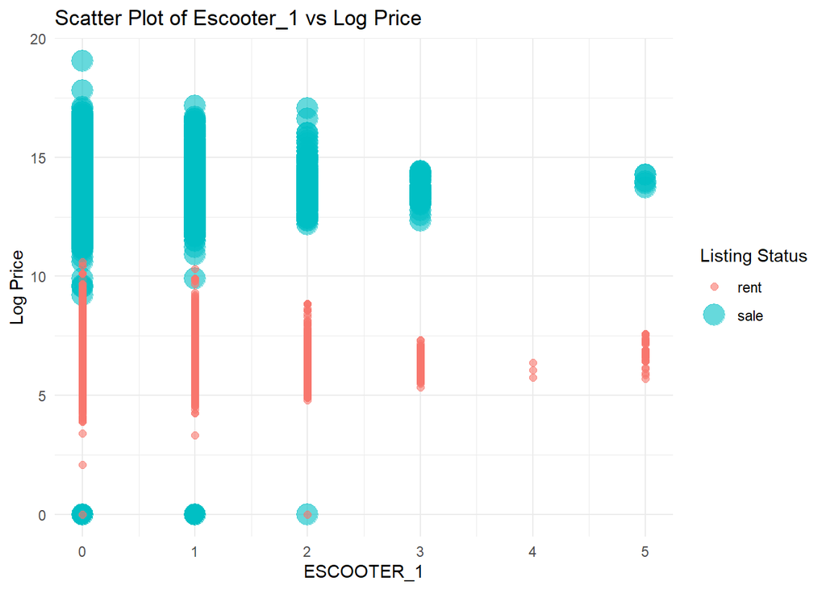

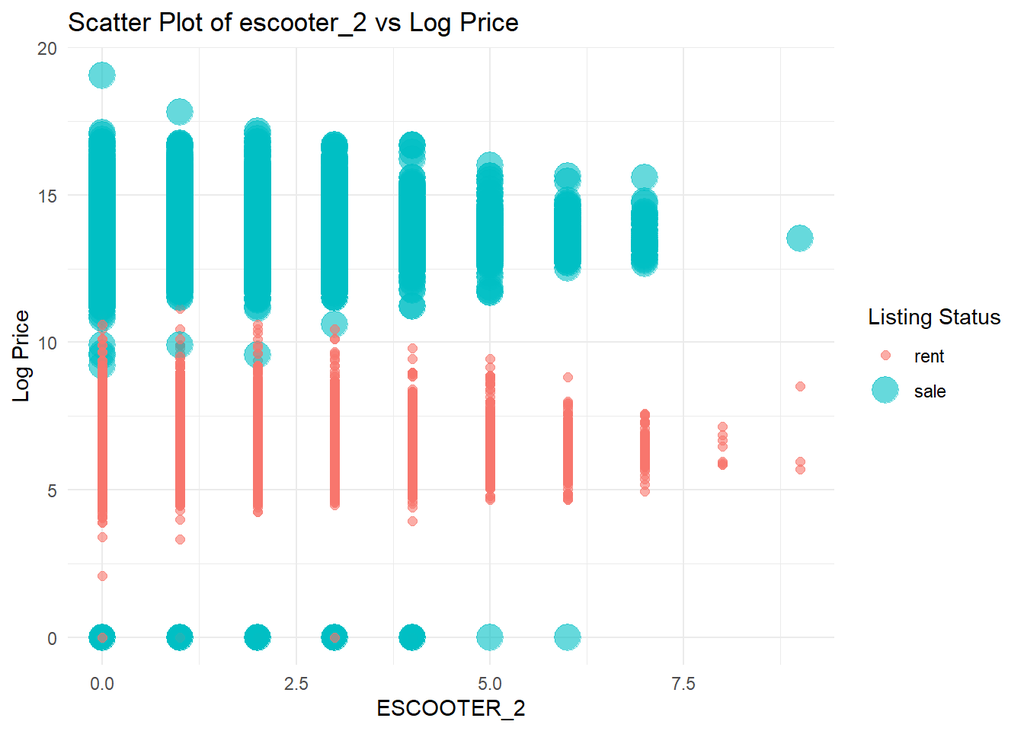

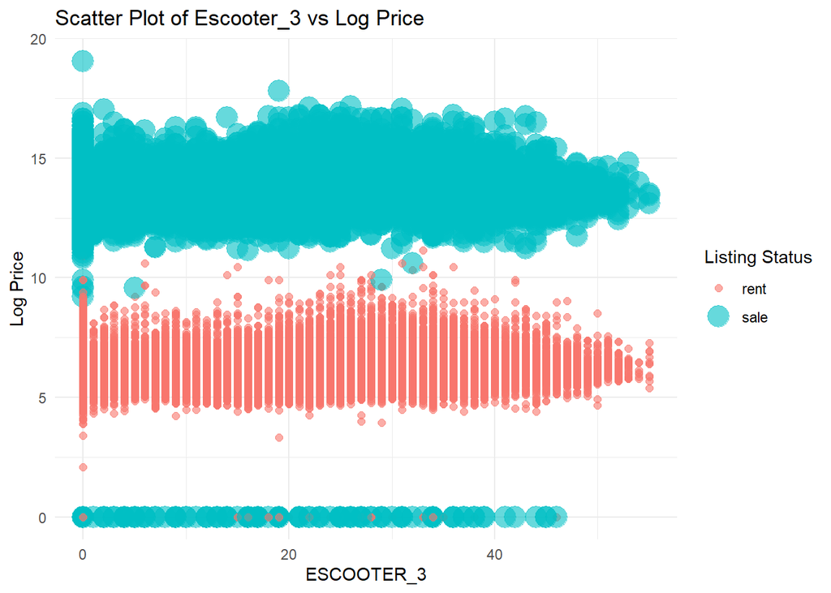

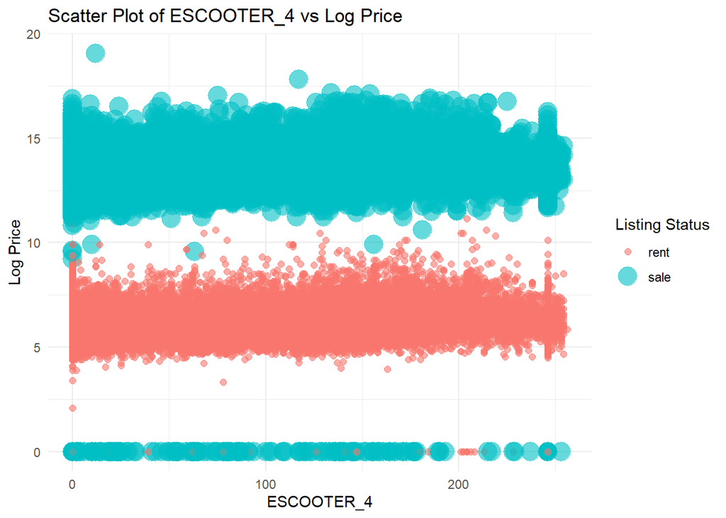

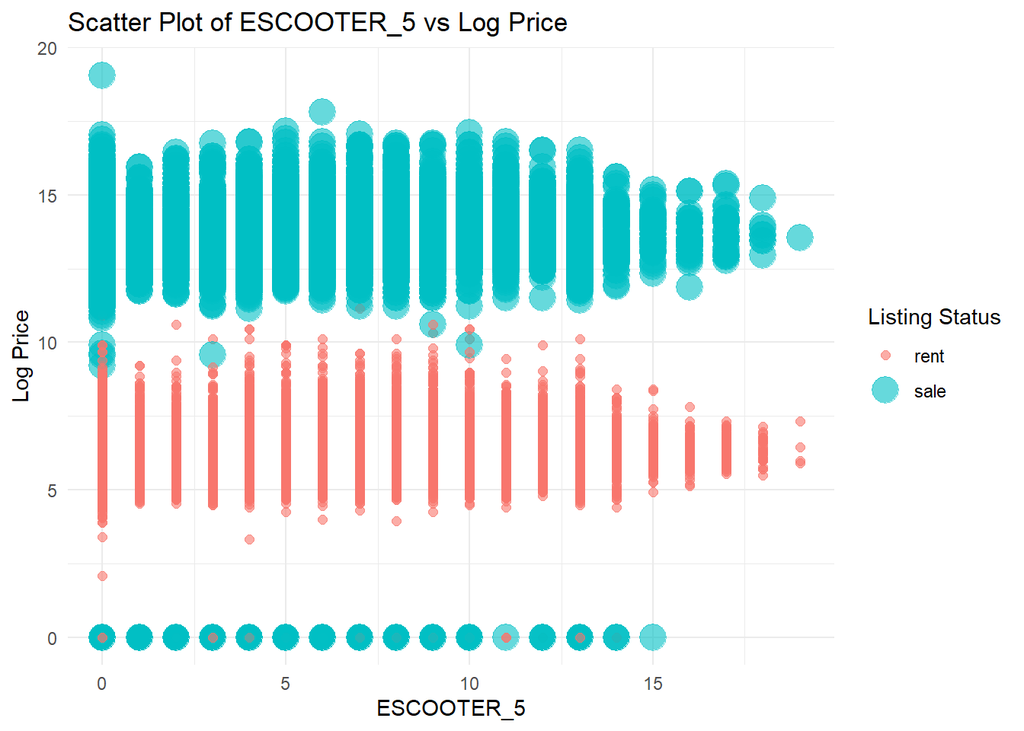

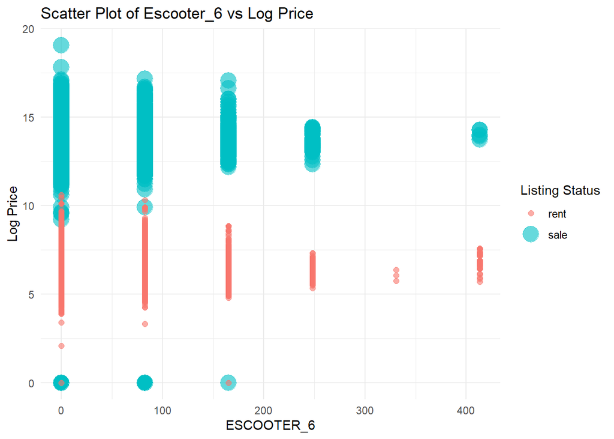

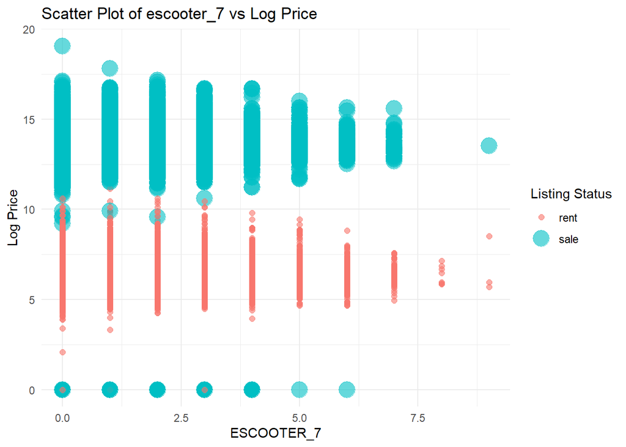

[figure not shown]

[figure not shown]

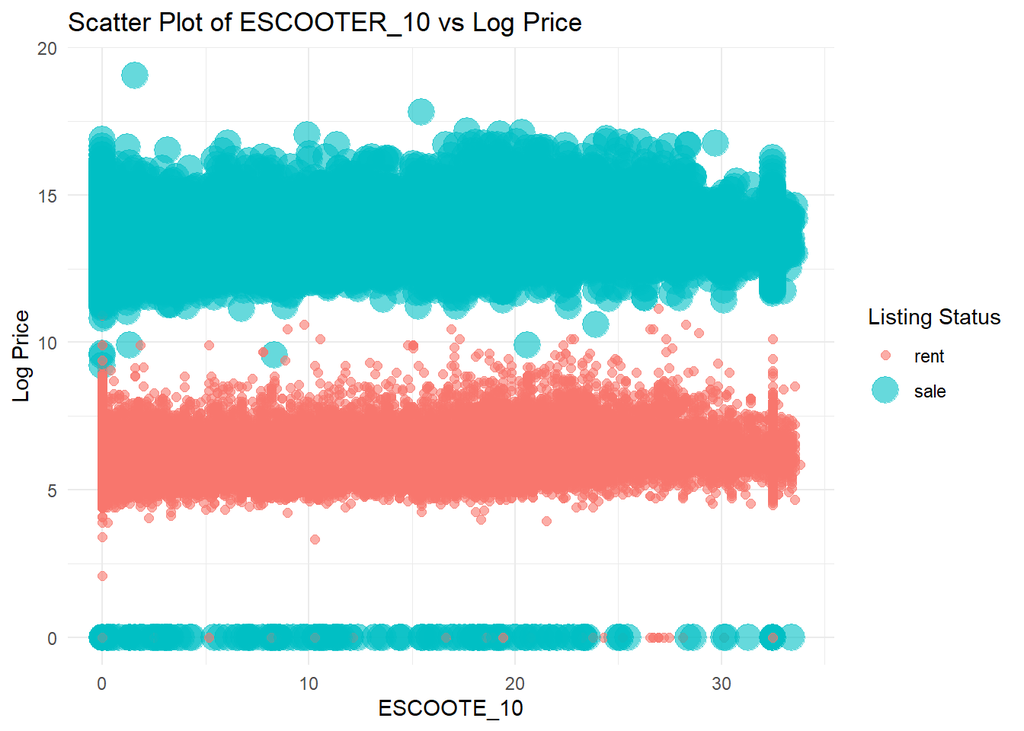

Interpretation: The graph displays the relationship between two variables Escooter_1 to E scooter_10 and “Log Price.” this suggests that as the value of each E-scooters at different distances increases, the log price remains relatively constant for both rental and sale listings. Also, the distinct clusters of data points indicate different pricing behaviors for rentals and sales

# creates correlation matrix

```
##                    PRICE  NUMBER_BED    NUM_FLOORS  NUM_BATHRO    NUM_RECEPT
## PRICE       1.0000000000  0.24338576 -0.0001424358 0.163413850  0.1508322866
## NUMBER_BED  0.2433857579  1.00000000  0.0705263231 0.413330484  0.2702267132
## NUM_FLOORS -0.0001424358  0.07052632  1.0000000000 0.100874100  0.0693450842
## NUM_BATHRO  0.1634138500  0.41333048  0.1008740995 1.000000000  0.5936156900
## NUM_RECEPT  0.1508322866  0.27022671  0.0693450842 0.593615690  1.0000000000
## BIKE_100   -0.0015245175 -0.03411869 -0.0093146893 0.021521254  0.0037721122
## BIKE_250    0.0099375027 -0.03244225 -0.0053971687 0.017355082  0.0008908126
## BIKE_500    0.0105462422 -0.05644133 -0.0028219632 0.022897247 -0.0057245295
## BIKE_1000   0.0236903999 -0.05993336 -0.0061148848 0.025893829 -0.0103367186
## BIKE_2500   0.0201997308 -0.06628023 -0.0082011788 0.026457103 -0.0190429332
## ESCOOTER_1 -0.0050233613 -0.05947259  0.0057509242 0.003789329 -0.0210457250
## escooter_2  0.0005928856 -0.08510392 -0.0010793623 0.019115345 -0.0379080688
## ESCOOTER_3  0.0079597557 -0.10166404 -0.0039622156 0.020340563 -0.0449642646
## ESCOOTER_4  0.0105376656 -0.10007467 -0.0051768030 0.014946333 -0.0464009315
## ESCOOTER_5  0.0009056313 -0.10167271 -0.0031361985 0.018901716 -0.0438370990
## ESCOOTER_6 -0.0050233613 -0.05947259  0.0057509242 0.003789329 -0.0210457250
## ESCOOTER_7  0.0005928856 -0.08510392 -0.0010793623 0.019115345 -0.0379080688
## ESCOOTER_8  0.0009056313 -0.10167271 -0.0031361985 0.018901716 -0.0438370990
## ESCOOTER_9  0.0079597557 -0.10166404 -0.0039622156 0.020340563 -0.0449642645
## ESCOOTE_10  0.0105376656 -0.10007467 -0.0051768030 0.014946333 -0.0464009315
##                BIKE_100      BIKE_250     BIKE_500    BIKE_1000    BIKE_2500
## PRICE      -0.001524518  0.0099375027  0.010546242  0.023690400  0.020199731
## NUMBER_BED -0.034118686 -0.0324422457 -0.056441333 -0.059933359 -0.066280231
## NUM_FLOORS -0.009314689 -0.0053971687 -0.002821963 -0.006114885 -0.008201179
## NUM_BATHRO  0.021521254  0.0173550817  0.022897247  0.025893829  0.026457103
## NUM_RECEPT  0.003772112  0.0008908126 -0.005724530 -0.010336719 -0.019042933
## BIKE_100    1.000000000  0.3296572426  0.261023552  0.219402071  0.208798245
## BIKE_250    0.329657243  1.0000000000  0.734514127  0.550947387  0.488720775
## BIKE_500    0.261023552  0.7345141274  1.000000000  0.777660628  0.683729595
## BIKE_1000   0.219402071  0.5509473874  0.777660628  1.000000000  0.786721064
## BIKE_2500   0.208798245  0.4887207748  0.683729595  0.786721064  1.000000000
## ESCOOTER_1  0.038304406  0.0729902839  0.096052291  0.144702694  0.162749047
## escooter_2  0.118002613  0.2423382856  0.336872492  0.390188666  0.553351928
## ESCOOTER_3  0.139515361  0.2979802482  0.425914252  0.514521213  0.661001142
## ESCOOTER_4  0.154091364  0.3320275164  0.454843902  0.493145980  0.721802748
## ESCOOTER_5  0.135407531  0.2908863689  0.428765665  0.453123235  0.655789959
## ESCOOTER_6  0.038304406  0.0729902839  0.096052291  0.144702694  0.162749047
## ESCOOTER_7  0.118002613  0.2423382856  0.336872492  0.390188666  0.553351928
## ESCOOTER_8  0.135407531  0.2908863689  0.428765665  0.453123235  0.655789959
```

[output cut: 29 more lines]

```
## BIKE_100    0.038304406  0.1180026126  0.1354075308  0.139515361  0.154091364
## BIKE_250    0.072990284  0.2423382856  0.2908863689  0.297980248  0.332027516
## BIKE_500    0.096052291  0.3368724916  0.4287656646  0.425914252  0.454843902
## BIKE_1000   0.144702694  0.3901886655  0.4531232354  0.514521213  0.493145980
## BIKE_2500   0.162749047  0.5533519278  0.6557899592  0.661001142  0.721802748
## ESCOOTER_1  1.000000000  0.3190402355  0.2657151246  0.275909950  0.247694550
## escooter_2  0.319040235  1.0000000000  0.8118204932  0.772417391  0.756971467
## ESCOOTER_3  0.275909950  0.7724173908  0.9017477231  1.000000000  0.912815563
## ESCOOTER_4  0.247694550  0.7569714666  0.8980707209  0.912815563  1.000000000
## ESCOOTER_5  0.265715125  0.8118204932  1.0000000000  0.901747723  0.898070721
## ESCOOTER_6  1.000000000  0.3190402355  0.2657151246  0.275909950  0.247694550
## ESCOOTER_7  0.319040235  1.0000000000  0.8118204932  0.772417391  0.756971467
## ESCOOTER_8  0.265715125  0.8118204932  1.0000000000  0.901747723  0.898070721
## ESCOOTER_9  0.275909950  0.7724173908  0.9017477231  1.000000000  0.912815563
## ESCOOTE_10  0.247694550  0.7569714666  0.8980707209  0.912815563  1.000000000
```

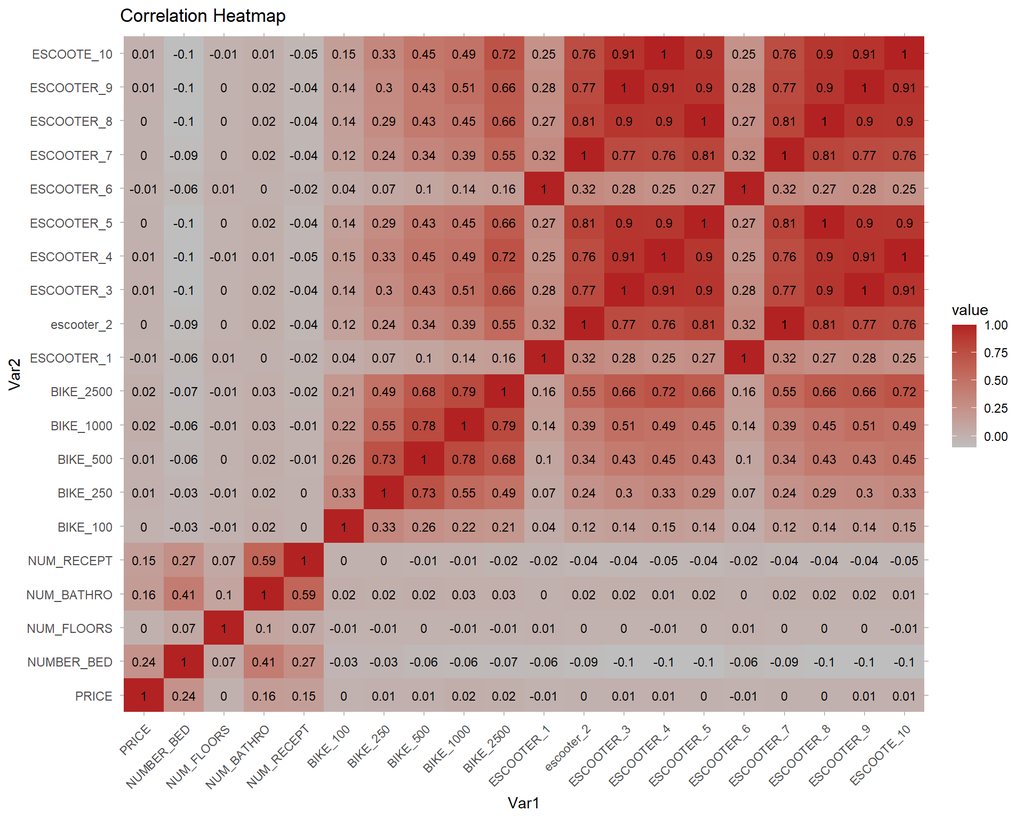

# summary interpretation of the correlation matrix Positive Correlations:

PRICE and NUMBER_BED (0.243): There is a moderate positive correlation between the property price and the number of bedrooms. Properties with more bedrooms tend to have higher prices, which is expected in real estate.

PRICE and NUM_BATHRO (0.163): There is a positive correlation between property price and the number of bathrooms. Properties with more bathrooms tend to have slightly higher prices.

PRICE and NUM_RECEPT (0.151): There is a positive correlation between property price and the number of reception rooms. Properties with more reception rooms may have slightly higher prices.

Negative Correlation: There are no significant negative correlations between price and other variables in the provided subset of the correlation matrix.

Correlations with Transportation Facilities:

BIKE_100, BIKE_250, BIKE_500, BIKE_1000, BIKE_2500: These variables show positive correlations with each other, indicating that the availability of bicycles within different distance ranges tends to be correlated. However, these variables show very weak correlations with property price.

ESCOOTER_1 to ESCOOTE_10: Similar to bicycles, electric scooter availability within different distance ranges shows positive correlations with each other but weak correlations with property price.

The strongest positive correlation with property price within this subset is with the number of bedrooms, followed by the number of bathrooms and reception rooms. Transportation facilities such as bicycles and electric scooters show weak correlations with property prices in this analysis, suggesting that these amenities may not strongly influence property prices in this context.

## Predicting Home Prices

### Hedonic Regressions

```
##      PRICE   BIKE_100   BIKE_250   BIKE_500  BIKE_1000 ESCOOTER_1 escooter_2
##          0          0          0          0          0          0          0
## ESCOOTER_5 ESCOOTER_3 ESCOOTER_4
##          0          0          0
```

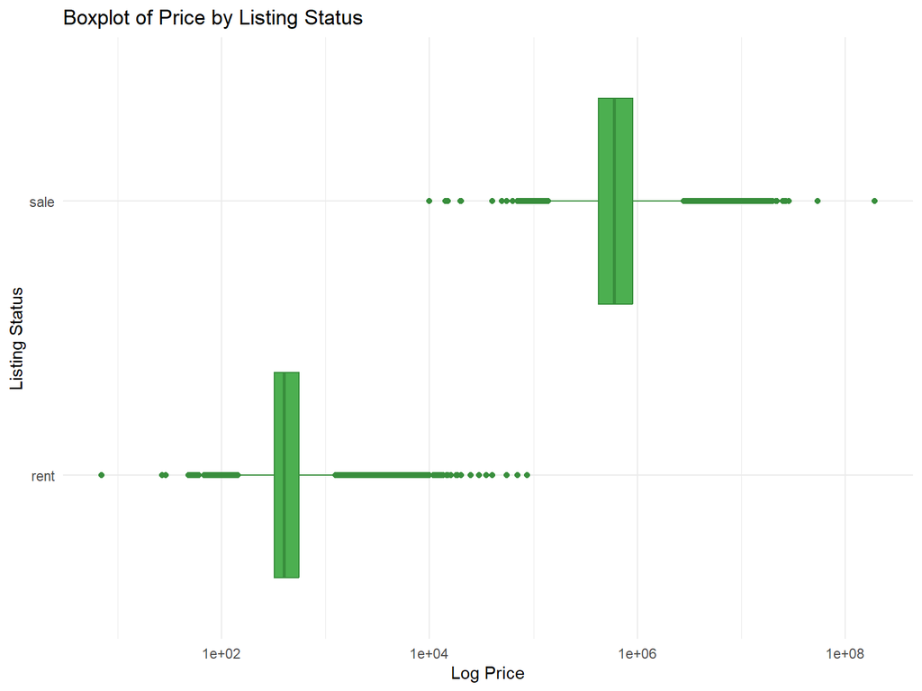

The box plot shows the distribution of the log Price for the categories of listing status.i can be noted from the plot that though the transformation gave a better spread of the price in each categories of the listing status with each exhibiting some amount of outliers.

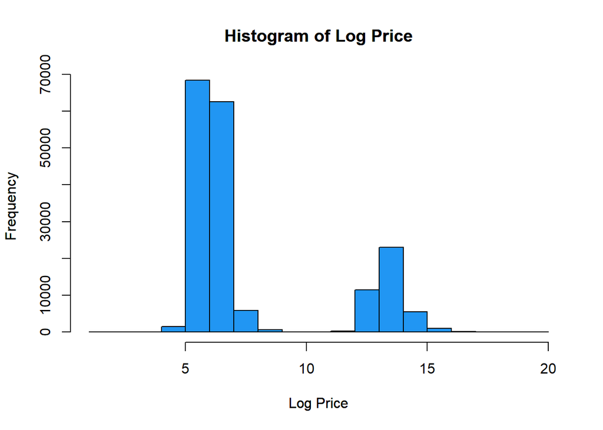

The histogram shows the distribution of the price after log transformation. it is worthy to note that the price distribution that was highly skewed with the original price is seen to have have a more distributed face given it a pattern less skewd than the original variable.

```
##  PRICE_log NUMBER_BED NUM_FLOORS NUM_BATHRO NUM_RECEPT   BIKE_100   BIKE_250
##          0          0          0          0          0          0          0
##   BIKE_500  BIKE_1000  BIKE_2500 ESCOOTER_1 escooter_2 ESCOOTER_5 ESCOOTER_3
##          0          0          0          0          0          0          0
## ESCOOTER_4 ESCOOTER_6 ESCOOTER_7 ESCOOTER_8 ESCOOTER_9 ESCOOTE_10
##          0          0          0          0          0          0
```

```
## tibble [180,523 × 20] (S3: tbl_df/tbl/data.frame)
##  $ PRICE_log : num [1:180523] 6.48 6.48 6.48 6.7 6.65 ...
##  $ NUMBER_BED: num [1:180523] 4 4 4 4 4 4 2 3 3 2 ...
##  $ NUM_FLOORS: num [1:180523] 0 0 0 0 0 0 0 2 2 0 ...
##  $ NUM_BATHRO: num [1:180523] 1 1 1 0 0 0 1 1 1 1 ...
##  $ NUM_RECEPT: num [1:180523] 1 1 1 0 0 0 1 0 0 1 ...
##  $ BIKE_100  : num [1:180523] 0 0 0 0 0 0 0 0 0 0 ...
##  $ BIKE_250  : num [1:180523] 3 3 3 3 0 0 0 0 0 0 ...
##  $ BIKE_500  : num [1:180523] 3 3 3 3 3 3 3 3 3 3 ...
##  $ BIKE_1000 : num [1:180523] 6 6 6 6 7 7 7 5 5 5 ...
##  $ BIKE_2500 : num [1:180523] 53 53 53 53 56 56 57 48 52 52 ...
##  $ ESCOOTER_1: num [1:180523] 0 0 0 0 0 0 0 0 0 0 ...
##  $ escooter_2: num [1:180523] 0 0 0 0 0 0 0 0 0 0 ...
##  $ ESCOOTER_5: num [1:180523] 2 2 2 2 4 4 5 1 2 2 ...
##  $ ESCOOTER_3: num [1:180523] 14 14 14 14 17 17 17 7 11 11 ...
##  $ ESCOOTER_4: num [1:180523] 97 97 97 97 104 104 108 83 89 89 ...
##  $ ESCOOTER_6: num [1:180523] 0 0 0 0 0 0 0 0 0 0 ...
##  $ ESCOOTER_7: num [1:180523] 0 0 0 0 0 0 0 0 0 0 ...
##  $ ESCOOTER_8: num [1:180523] 6.59 6.59 6.59 6.59 13.18 ...
##  $ ESCOOTER_9: num [1:180523] 11.6 11.6 11.6 11.6 14 ...
##  $ ESCOOTE_10: num [1:180523] 12.8 12.8 12.8 12.8 13.7 ...
```

```
##
## Call:
## lm(formula = PRICE_log ~ ., data = train_data)
##
## Residuals:
##      Min       1Q   Median       3Q      Max
## -22.4110  -1.8270  -1.3087  -0.1822  22.8053
##
## Coefficients: (5 not defined because of singularities)
##               Estimate Std. Error t value Pr(>|t|)
## (Intercept)  6.2570597  0.0213603 292.930  < 2e-16 ***
## NUMBER_BED   0.7327066  0.0077922  94.031  < 2e-16 ***
## NUM_FLOORS  -0.4038624  0.0150415 -26.850  < 2e-16 ***
## NUM_BATHRO  -0.3461620  0.0133134 -26.001  < 2e-16 ***
## NUM_RECEPT   0.7270973  0.0176087  41.292  < 2e-16 ***
## BIKE_100    -0.0442342  0.0226746  -1.951 0.051080 .
## BIKE_250     0.0072440  0.0115837   0.625 0.531737
## BIKE_500    -0.0100630  0.0059538  -1.690 0.090998 .
## BIKE_1000    0.0130204  0.0023413   5.561 2.68e-08 ***
## BIKE_2500   -0.0018651  0.0004788  -3.896 9.80e-05 ***
## ESCOOTER_1  -0.0616299  0.0217940  -2.828 0.004687 **
## escooter_2  -0.0082881  0.0117075  -0.708 0.478988
## ESCOOTER_5  -0.0205887  0.0055614  -3.702 0.000214 ***
## ESCOOTER_3  -0.0013517  0.0017430  -0.776 0.438024
## ESCOOTER_4   0.0013384  0.0003479   3.847 0.000120 ***
## ESCOOTER_6          NA         NA      NA       NA
## ESCOOTER_7          NA         NA      NA       NA
## ESCOOTER_8          NA         NA      NA       NA
## ESCOOTER_9          NA         NA      NA       NA
## ESCOOTE_10          NA         NA      NA       NA
## ---
## Signif. codes:  0 '***' 0.001 '**' 0.01 '*' 0.05 '.' 0.1 ' ' 1
##
## Residual standard error: 2.992 on 126351 degrees of freedom
## Multiple R-squared:  0.09265,    Adjusted R-squared:  0.09255
## F-statistic: 921.6 on 14 and 126351 DF,  p-value: < 2.2e-16
```

```
## [1] 8.948191
```

## Multi Collinearities

we can see there is Multi collinearities between some of our variable just as explained by the correlation matrix. it is expected we drop those variable that are col linear to others already contained in the model.due to this, the following will be dropped from the model ESCOOTER_6  
ESCOOTER_7  
ESCOOTER_8  
ESCOOTER_9  
ESCOOTE_10. Also very important to note that, while will use only the variables of interest alone, the R-squared:0.09265, Adjusted R-squared:0.09255 These values suggest that the independent variables in the model collectively explain about 9.26% of the variance in the dependent variable. which is very small but Considering these results,i try to Explore adding additional relevant variables to the model that could improve its explanatory power.

```
##  PRICE_log PROPERTY_T LISTING_ST NEAREST_ES NEAREST_BI NUMBER_BED NUM_FLOORS
##          0          0          0          0          0          0          0
## NUM_BATHRO NUM_RECEPT   BIKE_100   BIKE_250   BIKE_500  BIKE_1000  BIKE_2500
##          0          0          0          0          0          0          0
## ESCOOTER_1 escooter_2 ESCOOTER_5 ESCOOTER_3 ESCOOTER_4
##          0          0          0          0          0
```

```
## tibble [180,523 × 19] (S3: tbl_df/tbl/data.frame)
##  $ PRICE_log : num [1:180523] 6.48 6.48 6.48 6.7 6.65 ...
##  $ PROPERTY_T: chr [1:180523] "Flat" "Flat" "Flat" "Terraced house" ...
##  $ LISTING_ST: chr [1:180523] "rent" "rent" "rent" "rent" ...
##  $ NEAREST_ES: num [1:180523] 457 457 457 309 309 ...
##  $ NEAREST_BI: num [1:180523] 249 249 249 380 380 ...
##  $ NUMBER_BED: num [1:180523] 4 4 4 4 4 4 2 3 3 2 ...
##  $ NUM_FLOORS: num [1:180523] 0 0 0 0 0 0 0 2 2 0 ...
##  $ NUM_BATHRO: num [1:180523] 1 1 1 0 0 0 1 1 1 1 ...
##  $ NUM_RECEPT: num [1:180523] 1 1 1 0 0 0 1 0 0 1 ...
##  $ BIKE_100  : num [1:180523] 0 0 0 0 0 0 0 0 0 0 ...
##  $ BIKE_250  : num [1:180523] 3 3 3 3 0 0 0 0 0 0 ...
##  $ BIKE_500  : num [1:180523] 3 3 3 3 3 3 3 3 3 3 ...
##  $ BIKE_1000 : num [1:180523] 6 6 6 6 7 7 7 5 5 5 ...
##  $ BIKE_2500 : num [1:180523] 53 53 53 53 56 56 57 48 52 52 ...
##  $ ESCOOTER_1: num [1:180523] 0 0 0 0 0 0 0 0 0 0 ...
##  $ escooter_2: num [1:180523] 0 0 0 0 0 0 0 0 0 0 ...
##  $ ESCOOTER_5: num [1:180523] 2 2 2 2 4 4 5 1 2 2 ...
##  $ ESCOOTER_3: num [1:180523] 14 14 14 14 17 17 17 7 11 11 ...
##  $ ESCOOTER_4: num [1:180523] 97 97 97 97 104 104 108 83 89 89 ...
```

```
##
## Call:
## lm(formula = PRICE_log ~ ., data = train_data)
##
## Residuals:
##      Min       1Q   Median       3Q      Max
## -15.9356  -0.1883  -0.0181   0.1803   6.0832
##
## Coefficients:
##                                    Estimate Std. Error  t value Pr(>|t|)
## (Intercept)                       5.456e+00  1.226e-01   44.516  < 2e-16 ***
## PROPERTY_TBungalow               -6.616e-02  1.393e-01   -0.475  0.63473
## PROPERTY_TCottage                -9.675e-03  1.296e-01   -0.075  0.94051
## PROPERTY_TCountry house          -1.276e+00  6.123e-01   -2.084  0.03718 *
## PROPERTY_TDetached bungalow      -6.627e-02  2.066e-01   -0.321  0.74839
## PROPERTY_TDetached house         -3.880e-03  1.236e-01   -0.031  0.97495
## PROPERTY_TEnd terrace house      -1.510e-01  1.238e-01   -1.220  0.22235
## PROPERTY_TFlat                   -8.327e-02  1.225e-01   -0.680  0.49658
## PROPERTY_TLink-detached house    -1.558e-01  1.771e-01   -0.880  0.37892
## PROPERTY_TLodge                  -9.558e-01  6.122e-01   -1.561  0.11850
## PROPERTY_TMaisonette             -1.492e-01  1.229e-01   -1.214  0.22470
## PROPERTY_TMews house              2.861e-01  1.249e-01    2.291  0.02196 *
## PROPERTY_TSemi-detached bungalow -1.050e-01  1.699e-01   -0.618  0.53644
## PROPERTY_TSemi-detached house    -9.014e-02  1.231e-01   -0.732  0.46396
## PROPERTY_TStudio                 -1.336e-01  1.227e-01   -1.090  0.27591
## PROPERTY_TTerraced bungalow      -9.732e-02  2.949e-01   -0.330  0.74140
## PROPERTY_TTerraced house         -7.340e-02  1.227e-01   -0.598  0.54960
## PROPERTY_TTown house             -1.210e-01  1.238e-01   -0.977  0.32854
## LISTING_STsale                    7.160e+00  4.158e-03 1722.117  < 2e-16 ***
## NEAREST_ES                       -2.983e-05  1.233e-06  -24.200  < 2e-16 ***
## NEAREST_BI                       -8.192e-06  2.561e-06   -3.199  0.00138 **
## NUMBER_BED                        2.501e-01  2.058e-03  121.528  < 2e-16 ***
## NUM_FLOORS                       -3.750e-02  3.062e-03  -12.246  < 2e-16 ***
## NUM_BATHRO                        8.894e-02  2.734e-03   32.527  < 2e-16 ***
## NUM_RECEPT                        4.993e-02  3.620e-03   13.791  < 2e-16 ***
## BIKE_100                          6.180e-03  4.600e-03    1.343  0.17917
## BIKE_250                         -5.128e-03  2.324e-03   -2.207  0.02734 *
## BIKE_500                         -7.858e-03  1.197e-03   -6.567 5.15e-11 ***
## BIKE_1000                         9.440e-03  4.716e-04   20.016  < 2e-16 ***
## BIKE_2500                         5.565e-04  9.692e-05    5.742 9.41e-09 ***
## ESCOOTER_1                        4.542e-02  4.413e-03   10.294  < 2e-16 ***
## escooter_2                       -1.051e-02  2.348e-03   -4.477 7.59e-06 ***
## ESCOOTER_5                       -5.548e-03  1.116e-03   -4.969 6.73e-07 ***
## ESCOOTER_3                        4.670e-03  3.505e-04   13.321  < 2e-16 ***
## ESCOOTER_4                        6.052e-04  7.220e-05    8.382  < 2e-16 ***
## ---
## Signif. codes:  0 '***' 0.001 '**' 0.01 '*' 0.05 '.' 0.1 ' ' 1
##
## Residual standard error: 0.5998 on 126331 degrees of freedom
## Multiple R-squared:  0.9635, Adjusted R-squared:  0.9635
## F-statistic: 9.815e+04 on 34 and 126331 DF,  p-value: < 2.2e-16
```

Each PROPERTY type variable represents a different type of property (e.g., bungalow, cottage, detached house, flat, etc.). The “Estimate” column represents the coefficient estimate for each property type compared to a reference category. PROPERTY_TBungalow has a coefficient estimate of -0.06616. This means that, on average, bungalows have a slightly lower predicted value for the dependent variable compared to the reference category which is statistically significant if the p-value is less than 0.05.

The coefficient estimate of 7.160 indicates that properties listed for sale have, on average, a much higher predicted value for the dependent variable price compared to other listing statuses

The negative coefficient estimates (-2.983e-05 for NEAREST_ES and -8.192e-06 for NEAREST_BI) indicate that as the distance to these amenities increases, the predicted value for the dependent variable price decreases, although the effect is quite small due to the magnitude of the coefficients.

ESCOOTER_1 to ESCOOTER_5 - These variables represent the availability or density of electric scooters within specific distance ranges from the properties. ESCOOTER_1: The coefficient estimate of 0.04542 indicates that, on average, a one-unit increase in the availability/density of electric scooters within the specified range is associated with a 0.04542 unit increase in the predicted property price. This effect is statistically significant (p-value < 0.05), suggesting a meaningful impact on property prices. for escooter_2 to ESCOOTER_5, Similarly, these variables show varying impacts on property prices. For instance, a one-unit increase in escooter_2 is associated with a decrease in the predicted property price by -0.01051 units, as indicated by its negative coefficient estimate.

```
## R-squared: 0.9665028
```

```
## Root Mean Squared Error (RMSE): 0.5710539
```

```
## Mean Absolute Error (MAE): 0.2777029
```

# Result Interpretation

This study delves into the nuanced relationship between various property characteristics, listing status, proximity to amenities, and micromobility infrastructure on urban property values. the present study sets out to investigate the Modelling accuracy of HPM in property valuation.we analyze a dataset encompassing diverse property types and features in Inner London to uncover significant patterns and provide actionable insights for urban development policies. Our findings highlight the importance of micromobility infrastructure planning, property size and features, amenities proximity, and strategic listing approaches in enhancing property values and fostering sustainable urban development.

I utilized Hedonic Pricing Model, a Regression analysis techniques commonly use in property evaluation to analyze the comprehensive dataset comprising property characteristics (e.g., property type, size, features), listing status (sale vs. rent), proximity to amenities (e.g.,nearness to electric scooters, bikes), and micromobility infrastructure variables in Inner London. Statistical significance was determined based on p-values, with a conventional threshold of 0.05.

further more, the study evaluates the performance of a property valuation model to know how well the variable explained the variations in the dependent i.e. how well does the predictors explained the dependent variable using key metrics such as residual standard error, R-squared values, F-statistic, root mean squared error (RMSE), and mean absolute error (MAE). The model showcases a high level of explanatory power and accuracy in predicting property values.Assessing the effectiveness of a property valuation model through various performance metrics, shedding light on its predictive capabilities and reliability.

The RSE of 0.5998 on 126,331 degrees of freedom indicates the average deviation of observed values from the model’s predicted values. the Lower RSE values suggest a better fit of the model to the data. this umplies that the lower the RSE the better the model while the high values of 0.9635 for both multiple R-squared and adjusted R-squared indicate that the model explains approximately 96.35% of the variance in the dependent variable (property values),indicating strong explanatory power.

F-statistic of 9.815e+04 on 34 and 126,331 degrees of freedom, with a p-value < 2.2e-16, indicates that the overall regression model is statistically significant. This suggests that at least one independent variable in the model significantly contributes to predicting property values.

in conclusion,The high R-squared values, significant F-statistic, and low RMSE and MAE values collectively indicate that the property valuation model demonstrates strong predictive accuracy and reliability. It effectively captures variations in property values based on the specified independent variables. Real estate professionals and urban planners can rely on this model to make informed decisions regarding property valuation, investment strategies, and urban development planning.